# Advanced Statistical Learning for Physiological Stress Prediction

Jenna Lu

2026-07-27

# Overview

Predicting physiological stress requires models capable of identifying complex patterns in cardiovascular signals while remaining interpretable and statistically rigorous.

Previous notebooks introduced preprocessing, feature engineering, Bayesian modeling, mixed-effects models, and machine learning using heart rate data. This notebook synthesizes those analyses by comparing multiple statistical learning methods for stress classification across the WESAD dataset.

Objectives:

1. Engineer informative heart rate features
2. Explore feature relationships
3. Visualize physiological structure using PCA
4. Compare multiple statistical learning algorithms
5. Evaluate predictive performance

# Libraries

```r
library(tidyverse)
library(here)
library(pROC)
library(MASS)
library(class)
library(rpart)
library(rpart.plot)
library(brms)
```

# Load Heart Rate Files

```r
# Load Heart Rate Files

hr_files <- list.files(
  here("data","processed"),
  pattern="_heart_rate.csv$",
  full.names=TRUE
)


hr_all <- purrr::map_dfr(
  hr_files,
  function(file){

    subject <- stringr::str_extract(
      basename(file),
      "S[0-9]+"
    )

    read_csv(
      file,
      show_col_types = FALSE
    ) %>%
      mutate(
        subject = subject
      )

  }
)


glimpse(hr_all)
```

```
## Rows: 104,632
## Columns: 3
## $ time       <dbl> 1.562857, 2.195714, 2.821429, 3.445714, 4.072857, 4.697143,…
## $ heart_rate <dbl> 94.59459, 94.80813, 95.89041, 96.10984, 95.67198, 96.10984,…
## $ subject    <chr> "S10", "S10", "S10", "S10", "S10", "S10", "S10", "S10", "S1…
```

# Load Condition Labels

```r
condition_files <- list.files(
  here("data","processed"),
  pattern="_ecg_filtered.csv$",
  full.names=TRUE
)


condition_all <- purrr::map_dfr(

  condition_files,

  function(file){

    subject <- stringr::str_extract(
      basename(file),
      "S[0-9]+"
    )

    read_csv(
      file,
      show_col_types = FALSE
    ) %>%
      dplyr::select(
        time,
        label
      ) %>%
      mutate(
        subject=subject
      )

  }

)


head(condition_all)
```

```
## # A tibble: 6 × 3
##      time label subject
##     <dbl> <dbl> <chr>
## 1 0           0 S10
## 2 0.00143     0 S10
## 3 0.00286     0 S10
## 4 0.00429     0 S10
## 5 0.00571     0 S10
## 6 0.00714     0 S10
```

# Match Heart Rate with Experimental Labels

```r
hr_condition <- hr_all %>%

group_by(subject) %>%

group_modify(

~{

labels <- condition_all %>%
filter(subject == .y$subject) %>%
arrange(time)


if(nrow(labels)==0){

return(tibble())

}


.x %>%
mutate(

label = labels$label[
findInterval(
time,
labels$time
)
]

)

}

) %>%

ungroup() %>%

filter(!is.na(label))


head(hr_condition)
```

```
## # A tibble: 6 × 4
##   subject  time heart_rate label
##   <chr>   <dbl>      <dbl> <dbl>
## 1 S10      1.56       94.6     0
## 2 S10      2.20       94.8     0
## 3 S10      2.82       95.9     0
## 4 S10      3.45       96.1     0
## 5 S10      4.07       95.7     0
## 6 S10      4.70       96.1     0
```

# Create Binary Stress Outcome

```r
model_data <- hr_condition %>%

  mutate(

    stress=factor(

      ifelse(
        label==2,
        "Stress",
        "Non-Stress"
      )

    )

  )

table(model_data$stress)
```

```
##
## Non-Stress     Stress
##      91172      13460
```

# Feature Engineering

Each one-minute window is summarized using descriptive statistics.

```r
features <- model_data %>%

  mutate(
    window=floor(time/60)
  ) %>%

  group_by(
    subject,
    window,
    stress
  ) %>%

  summarise(

    mean_hr=mean(heart_rate),

    median_hr=median(heart_rate),

    sd_hr=sd(heart_rate),

    min_hr=min(heart_rate),

    max_hr=max(heart_rate),

    range_hr=max_hr-min_hr,

    iqr_hr=IQR(heart_rate),

    .groups="drop"

  ) %>%
  mutate(
    range_hr = max_hr - min_hr,
    cv_hr = sd_hr / mean_hr
  )

head(features)
```

```
## # A tibble: 6 × 11
##   subject window stress    mean_hr median_hr sd_hr min_hr max_hr range_hr iqr_hr
##   <chr>    <dbl> <fct>       <dbl>     <dbl> <dbl>  <dbl>  <dbl>    <dbl>  <dbl>
## 1 S10          0 Non-Stre…    92.8      97.4  17.1   30.5   103.     72.1   6.85
## 2 S10          1 Non-Stre…    90.7      92.3  13.8   31.3   107.     76.1  12.2
## 3 S10          2 Non-Stre…    90.5      95.5  17.8   31.3   106.     74.5   5.80
## 4 S10          3 Non-Stre…    95.0     101.   17.6   48.5   109.     60.9   4.08
## 5 S10          4 Non-Stre…    91.8      97.6  17.4   46.3   111.     64.6  16.9
## 6 S10          5 Non-Stre…    94.9      97.7  10.8   47.7   104.     56.5   6.05
## # ℹ 1 more variable: cv_hr <dbl>
```

# Feature Summary

```r
summary(features)
```

```
##    subject              window              stress        mean_hr
##  Length:1479        Min.   :  0.00   Non-Stress:1297   Min.   : 49.05
##  Class :character   1st Qu.: 24.00   Stress    : 182   1st Qu.: 66.37
##  Mode  :character   Median : 48.00                     Median : 73.91
##                     Mean   : 48.28                     Mean   : 75.33
##                     3rd Qu.: 71.00                     3rd Qu.: 83.52
##                     Max.   :117.00                     Max.   :120.00
##
##    median_hr          sd_hr             min_hr           max_hr
##  Min.   : 46.44   Min.   : 0.4893   Min.   : 30.02   Min.   : 61.58
##  1st Qu.: 66.06   1st Qu.: 5.6015   1st Qu.: 47.48   1st Qu.: 82.19
##  Median : 73.43   Median : 7.6027   Median : 57.14   Median : 91.70
##  Mean   : 75.59   Mean   : 8.9678   Mean   : 55.88   Mean   : 92.40
##  3rd Qu.: 83.67   3rd Qu.:10.7357   3rd Qu.: 64.42   3rd Qu.:101.45
##  Max.   :120.00   Max.   :31.9542   Max.   :120.00   Max.   :120.00
##                   NA's   :1
##     range_hr         iqr_hr           cv_hr
##  Min.   : 0.00   Min.   : 0.000   Min.   :0.008007
##  1st Qu.:24.18   1st Qu.: 6.672   1st Qu.:0.075886
##  Median :32.18   Median : 9.216   Median :0.102101
##  Mean   :36.52   Mean   :11.452   Mean   :0.119308
##  3rd Qu.:43.94   3rd Qu.:13.304   3rd Qu.:0.143662
##  Max.   :89.89   Max.   :57.937   Max.   :0.370047
##                                   NA's   :1
```

# Distribution of Heart Rate

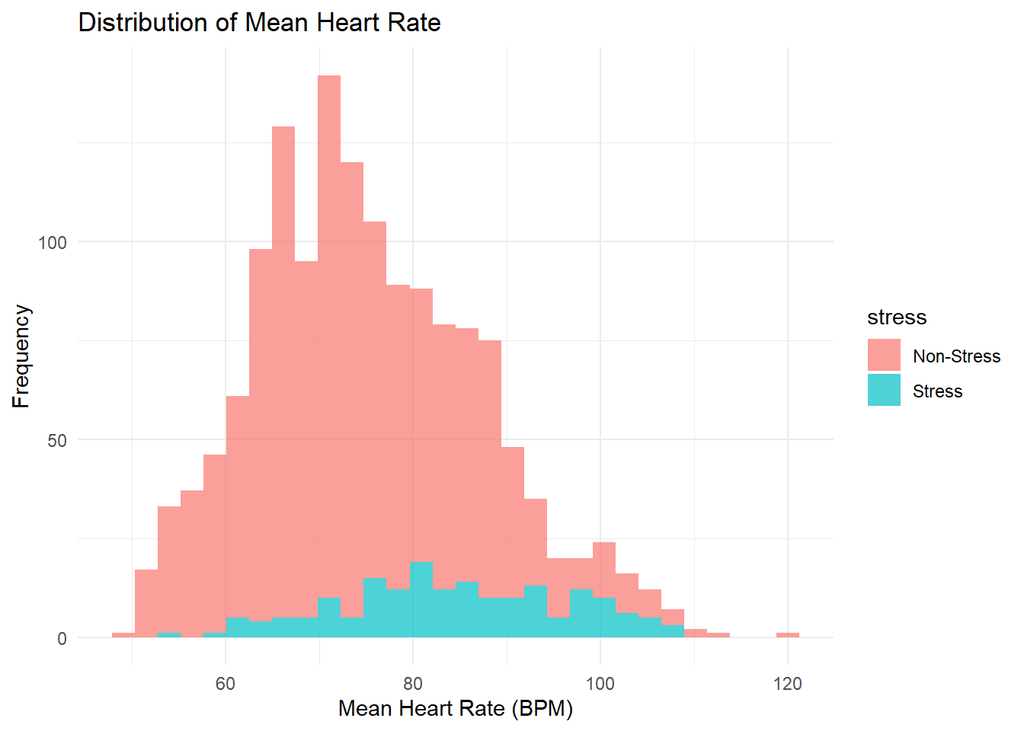

```r
ggplot(

  features,

  aes(
    mean_hr,
    fill=stress
  )

)+

geom_histogram(
  bins=30,
  alpha=.7
)+

theme_minimal()+

labs(

title="Distribution of Mean Heart Rate",

x="Mean Heart Rate (BPM)",

y="Frequency"

)
```

# Boxplots

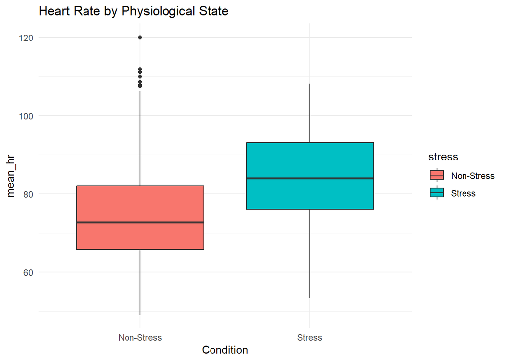

```r
ggplot(

features,

aes(

stress,

mean_hr,

fill=stress

)

)+

geom_boxplot()+

theme_minimal()+

labs(

title="Heart Rate by Physiological State",

x="Condition",


)
```

# Correlation Matrix

```r
numeric_features <- features %>%
  dplyr::select(
    mean_hr,
    median_hr,
    sd_hr,
    min_hr,
    max_hr,
    range_hr,
    iqr_hr,
    cv_hr
  ) %>%
  mutate(
    across(
      everything(),
      ~replace(.x, is.infinite(.x), NA)
    )
  ) %>%
  drop_na()


# Remove zero variance columns
numeric_features <- numeric_features[
  sapply(
    numeric_features,
    function(x) sd(x) > 0
  )
]


cor_matrix <- cor(numeric_features)

round(cor_matrix,2)
```

```
##           mean_hr median_hr sd_hr min_hr max_hr range_hr iqr_hr cv_hr
## mean_hr      1.00      0.97  0.29   0.45   0.83     0.34   0.18 -0.02
## median_hr    0.97      1.00  0.34   0.35   0.79     0.38   0.20  0.03
## sd_hr        0.29      0.34  1.00  -0.55   0.64     0.90   0.74  0.94
## min_hr       0.45      0.35 -0.55   1.00   0.13    -0.61  -0.29 -0.70
## max_hr       0.83      0.79  0.64   0.13   1.00     0.70   0.44  0.42
## range_hr     0.34      0.38  0.90  -0.61   0.70     1.00   0.56  0.83
## iqr_hr       0.18      0.20  0.74  -0.29   0.44     0.56   1.00  0.71
## cv_hr       -0.02      0.03  0.94  -0.70   0.42     0.83   0.71  1.00
```

# Correlation Heatmap

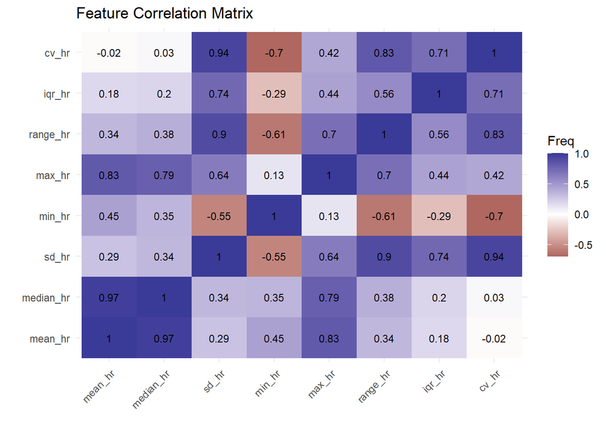

```r
cor_df <-

as.data.frame(as.table(cor_matrix))

ggplot(

cor_df,

aes(

Var1,

Var2,

fill=Freq

)

)+

geom_tile()+

geom_text(

aes(label=round(Freq,2)),

size=3

)+

scale_fill_gradient2()+

theme_minimal()+

theme(

axis.text.x=

element_text(

angle=45,

hjust=1

)

)+

labs(

title="Feature Correlation Matrix",

x="",

y=""

)
```

# Principal Component Analysis

```r
pca <- prcomp(
  numeric_features,
  scale. = TRUE
)

summary(pca)
```

```
## Importance of components:
##                           PC1    PC2     PC3     PC4     PC5    PC6     PC7
## Standard deviation     2.0954 1.6335 0.77479 0.45114 0.33333 0.1296 0.09590
## Proportion of Variance 0.5488 0.3336 0.07504 0.02544 0.01389 0.0021 0.00115
## Cumulative Proportion  0.5488 0.8824 0.95742 0.98286 0.99675 0.9989 1.00000
##                             PC8
## Standard deviation     1.62e-15
## Proportion of Variance 0.00e+00
## Cumulative Proportion  1.00e+00
```

# PCA Visualization

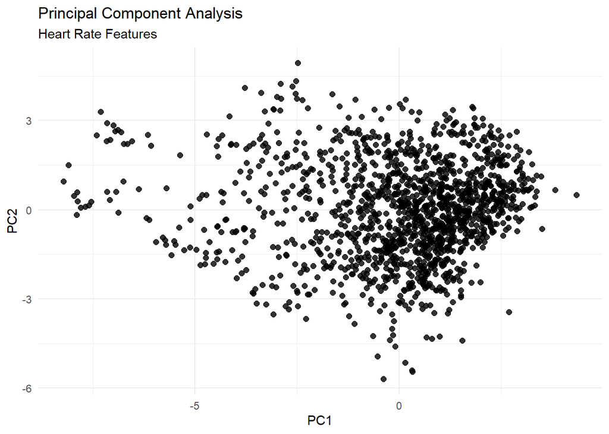

```r
pca_df <- data.frame(
  PC1 = pca$x[,1],
  PC2 = pca$x[,2]
)


ggplot(
  pca_df,
  aes(
    PC1,
    PC2
  )
)+
geom_point(
  alpha=.8,
  size=2
)+
theme_minimal()+
labs(
  title="Principal Component Analysis",
  subtitle="Heart Rate Features"
)
```

# Create Training and Testing Sets

```r
# Remove invalid feature values before modeling

features <- features %>%
  mutate(
    across(
      c(
        mean_hr,
        median_hr,
        sd_hr,
        min_hr,
        max_hr,
        range_hr,
        iqr_hr,
        cv_hr
      ),
      ~replace(.x, is.infinite(.x), NA)
    )
  ) %>%
  drop_na()

set.seed(123)

subjects <- unique(features$subject)

train_subjects <- sample(
  subjects,
  size = floor(0.75 * length(subjects))
)

train <- features %>%
  filter(subject %in% train_subjects)

test <- features %>%
  filter(!subject %in% train_subjects)
```

# Next

The following sections compare several statistical learning algorithms:

- Logistic Regression
- Linear Discriminant Analysis
- Quadratic Discriminant Analysis
- k-Nearest Neighbors
- Decision Trees

using the same training and testing data.

# Logistic Regression

```r
log_model <- glm(
  stress ~ mean_hr +
    median_hr +
    sd_hr +
    min_hr +
    max_hr +
    range_hr +
    iqr_hr +
    cv_hr,
  data = train,
  family = binomial()
)

summary(log_model)
```

```
##
## Call:
## glm(formula = stress ~ mean_hr + median_hr + sd_hr + min_hr +
##     max_hr + range_hr + iqr_hr + cv_hr, family = binomial(),
##     data = train)
##
## Coefficients: (1 not defined because of singularities)
##              Estimate Std. Error z value Pr(>|z|)
## (Intercept) -15.23815    1.96335  -7.761 8.41e-15 ***
## mean_hr       0.01954    0.04517   0.433  0.66532
## median_hr     0.02913    0.02565   1.136  0.25609
## sd_hr        -0.38719    0.18794  -2.060  0.03938 *
## min_hr        0.01242    0.01335   0.930  0.35219
## max_hr        0.07745    0.02421   3.199  0.00138 **
## range_hr           NA         NA      NA       NA
## iqr_hr        0.01224    0.01467   0.834  0.40424
## cv_hr        36.29946   16.04227   2.263  0.02365 *
## ---
## Signif. codes:  0 '***' 0.001 '**' 0.01 '*' 0.05 '.' 0.1 ' ' 1
##
## (Dispersion parameter for binomial family taken to be 1)
##
##     Null deviance: 811.41  on 1070  degrees of freedom
## Residual deviance: 641.32  on 1063  degrees of freedom
## AIC: 657.32
##
## Number of Fisher Scoring iterations: 6
```

# Logistic Regression Predictions

```r
log_prob <- predict(
  log_model,
  newdata = test,
  type = "response"
)
log_pred <- factor(
  ifelse(log_prob > 0.5,
         "Stress",
         "Non-Stress"),
  levels = levels(test$stress)
)

log_auc <- roc(
  response = test$stress,
  predictor = log_prob
)
auc(log_auc)
```

```
## Area under the curve: 0.8431
```

# Logistic Regression Confusion Matrix

```r
table(
  Actual = test$stress,
  Predicted = log_pred
)
```

```
##             Predicted
## Actual       Non-Stress Stress
##   Non-Stress        352      8
##   Stress             45      2
```

# Linear Discriminant Analysis

```r
lda_model <- lda(
  stress ~ mean_hr +
    median_hr +
    sd_hr +
    min_hr +
    max_hr +
    range_hr +
    iqr_hr +
    cv_hr,
  data = train
)
lda_model
```

```
## Call:
## lda(stress ~ mean_hr + median_hr + sd_hr + min_hr + max_hr +
##     range_hr + iqr_hr + cv_hr, data = train)
##
## Prior probabilities of groups:
## Non-Stress     Stress
##  0.8739496  0.1260504
##
## Group means:
##             mean_hr median_hr     sd_hr   min_hr    max_hr range_hr   iqr_hr
## Non-Stress 77.37641  77.47924  8.262525 58.88753  93.31385 34.42632 10.65985
## Stress     85.40456  86.16044 13.657200 55.93071 108.22269 52.29197 17.16137
##                cv_hr
## Non-Stress 0.1058547
## Stress     0.1628427
##
## Coefficients of linear discriminants:
##                    LD1
## mean_hr   -0.036897159
## median_hr  0.022639819
## sd_hr     -0.039827915
## min_hr     0.030985674
## max_hr     0.052828387
## range_hr   0.013133787
## iqr_hr     0.005525098
## cv_hr     11.483224094
```

# LDA Predictions

```r
lda_pred <- predict(
  lda_model,
  newdata = test
)

lda_class <- lda_pred$class

lda_auc <- roc(
  response = test$stress,
  predictor = lda_pred$posterior[, "Stress"]
)
auc(lda_auc)
```

```
## Area under the curve: 0.8213
```

# LDA Confusion Matrix

```r
table(
  Actual = test$stress,
  Predicted = lda_class
)
```

```
##             Predicted
## Actual       Non-Stress Stress
##   Non-Stress        350     10
##   Stress             44      3
```

# Quadratic Discriminant Analysis

```r
qda_result <- tryCatch({

  qda_model <- qda(
    stress ~ mean_hr +
      median_hr +
      sd_hr +
      min_hr +
      max_hr +
      range_hr +
      iqr_hr +
      cv_hr,
    data = train
  )

  qda_model

}, error = function(e){

  message("QDA failed: insufficient samples for covariance estimation.")

  NULL

})
```

```
## QDA failed: insufficient samples for covariance estimation.
```

# QDA Predictions (if covariance estimation succeeds)

```r
if(!is.null(qda_result)){

qda_pred <- predict(
  qda_result,
  newdata=test
)

qda_class <- qda_pred$class

qda_auc <- roc(
  response=test$stress,
  predictor=qda_pred$posterior[, "Stress"]
)

auc(qda_auc)

}
```

# QDA Confusion Matrix

```r
if(exists("qda_class")){

table(
  Actual = test$stress,
  Predicted = qda_class
)

}
```

# Compare Classical Statistical Models

```r
tibble(

  Model = c(
    "Logistic Regression",
    "Linear Discriminant Analysis",
    "Quadratic Discriminant Analysis"
  ),

  AUC = c(
    as.numeric(auc(log_auc)),
    as.numeric(auc(lda_auc)),
    ifelse(
      exists("qda_auc"),
      as.numeric(auc(qda_auc)),
      NA
    )
  )

)
```

```
## # A tibble: 3 × 2
##   Model                              AUC
##   <chr>                            <dbl>
## 1 Logistic Regression              0.843
## 2 Linear Discriminant Analysis     0.821
## 3 Quadratic Discriminant Analysis NA
```

# ROC Comparison

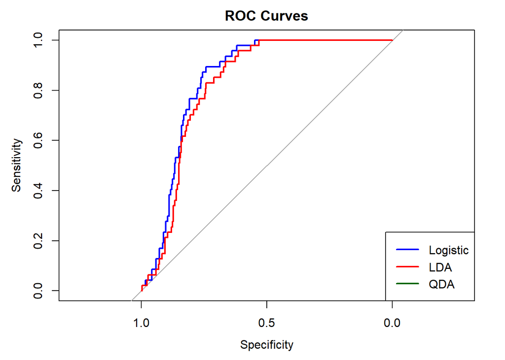

```r
plot(
  log_auc,
  col = "blue",
  lwd = 2,
  main = "ROC Curves"
)

plot(
  lda_auc,
  col = "red",
  lwd = 2,
  add = TRUE
)

if(exists("qda_auc")){

plot(
  qda_auc,
  col = "darkgreen",
  lwd = 2,
  add = TRUE
)

}

legend(

  "bottomright",

  legend = c(
    "Logistic",
    "LDA",
    "QDA"
  ),

  col = c(
    "blue",
    "red",
    "darkgreen"
  ),

  lwd = 2

)
```

# Interpretation

The three classical statistical learning methods make different assumptions regarding the relationship between physiological predictors and stress.

Logistic regression models the probability of stress directly through a generalized linear model. LDA assumes that each class follows a multivariate normal distribution with a common covariance matrix, whereas QDA relaxes this assumption by estimating separate covariance structures for each class.

Comparing these approaches provides insight into whether increasing model flexibility improves predictive performance for physiological stress classification.

# k-Nearest Neighbors

Unlike the previous methods, k-nearest neighbors is a nonparametric algorithm that classifies observations according to their nearest neighbors in feature space.

```r
train_x <- train %>%
  dplyr::select(
    -stress,
    -subject,
    -window
  )

test_x <- test %>%
  dplyr::select(
    -stress,
    -subject,
    -window
  )


train_scaled <- scale(train_x)

test_scaled <- scale(
  test_x,
  center = attr(train_scaled, "scaled:center"),
  scale = attr(train_scaled, "scaled:scale")
)


# Keep only complete observations

train_complete <- complete.cases(train_scaled)
test_complete <- complete.cases(test_scaled)


train_scaled <- train_scaled[train_complete,]
test_scaled <- test_scaled[test_complete,]

train_stress <- train$stress[train_complete]
test_stress <- test$stress[test_complete]
```

# Fit kNN

```r
k <- 5
knn_pred <- knn(
  train = train_scaled,
  test = test_scaled,
  cl = train_stress,
  k = k,
  prob = TRUE
)
```

# Evaluate kNN

```r
table(
  Actual = test_stress,
  Predicted = knn_pred
)
```

```
##             Predicted
## Actual       Non-Stress Stress
##   Non-Stress        343     17
##   Stress             44      3
```

```r
knn_prob <- ifelse(
  knn_pred == "Stress",
  attr(knn_pred, "prob"),
  1 - attr(knn_pred, "prob")
)

knn_auc <- roc(
  response = test$stress,
  predictor = knn_prob
)
auc(knn_auc)
```

```
## Area under the curve: 0.6278
```

# Decision Tree

Decision trees recursively partition the feature space into regions with similar physiological responses.

```r
tree_model <- rpart(
  stress ~ mean_hr +
    median_hr +
    sd_hr +
    min_hr +
    max_hr +
    range_hr +
    iqr_hr +
    cv_hr,
  data = train,
  method = "class"
)

tree_model
```

```
## n= 1071
##
## node), split, n, loss, yval, (yprob)
##       * denotes terminal node
##
##  1) root 1071 135 Non-Stress (0.87394958 0.12605042)
##    2) max_hr< 117.4827 975  77 Non-Stress (0.92102564 0.07897436) *
##    3) max_hr>=117.4827 96  38 Stress (0.39583333 0.60416667)
##      6) mean_hr>=83.92216 70  35 Non-Stress (0.50000000 0.50000000)
##       12) median_hr< 98.88344 18   5 Non-Stress (0.72222222 0.27777778) *
##       13) median_hr>=98.88344 52  22 Stress (0.42307692 0.57692308)
##         26) median_hr>=109.375 26  11 Non-Stress (0.57692308 0.42307692)
##           52) iqr_hr< 10.35379 12   3 Non-Stress (0.75000000 0.25000000) *
##           53) iqr_hr>=10.35379 14   6 Stress (0.42857143 0.57142857) *
##         27) median_hr< 109.375 26   7 Stress (0.26923077 0.73076923) *
##      7) mean_hr< 83.92216 26   3 Stress (0.11538462 0.88461538) *
```

# Visualize Decision Tree

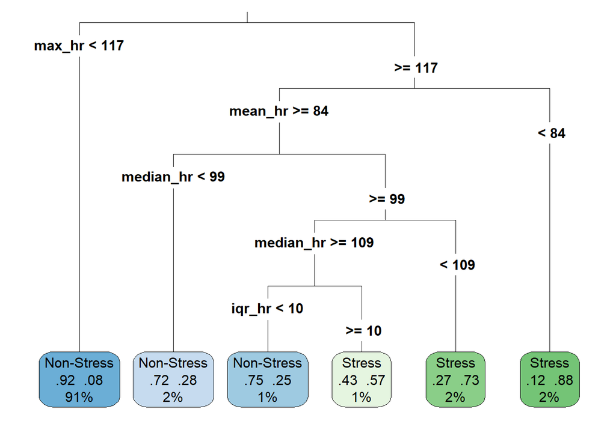

```r
rpart.plot(
  tree_model,
  type = 3,
  fallen.leaves = TRUE,
  extra = 104
)
```

# Evaluate Decision Tree

```r
tree_prob <- predict(
  tree_model,
  newdata = test,
  type = "prob"
)

tree_pred <- predict(
  tree_model,
  newdata = test,
  type = "class"
)

table(
  Actual = test_stress,
  Predicted = tree_pred
)
```

```
##             Predicted
## Actual       Non-Stress Stress
##   Non-Stress        351      9
##   Stress             44      3
```

```r
tree_auc <- roc(
  response = test$stress,
  predictor = tree_prob[, "Stress"]
)
auc(tree_auc)
```

```
## Area under the curve: 0.5179
```

# Variable Importance

```r
importance <- tree_model$variable.importance

importance_df <- tibble(
  Feature = names(importance),
  Importance = as.numeric(importance)
)

importance_df
```

```
## # A tibble: 8 × 2
##   Feature   Importance
##   <chr>          <dbl>
## 1 max_hr        49.2
## 2 range_hr      33.7
## 3 median_hr     31.5
## 4 sd_hr         25.3
## 5 cv_hr         22.7
## 6 iqr_hr        19.1
## 7 mean_hr        8.68
## 8 min_hr         0.929
```

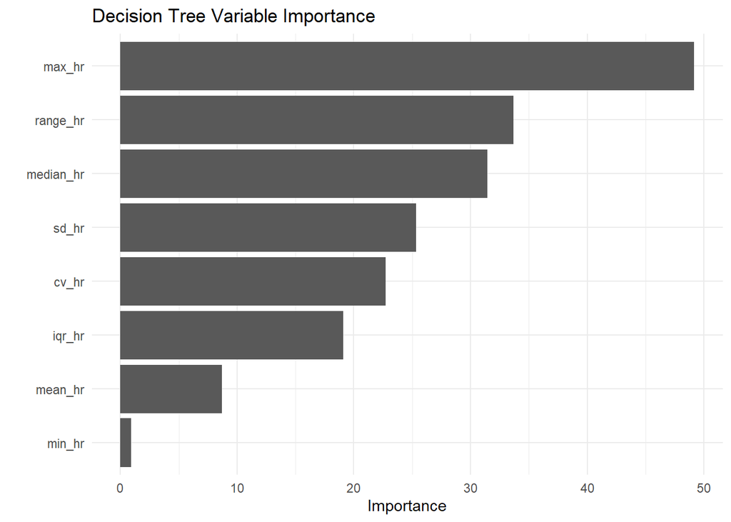

```r
ggplot(
  importance_df,
  aes(
    reorder(Feature, Importance),
    Importance
  )
) +
  geom_col() +
  coord_flip() +
  theme_minimal() +
  labs(
    title = "Decision Tree Variable Importance",
    x = "",
    y = "Importance"
)
```

# Overall Model Comparison

```r
results <- tibble(

  Model = c(
    "Logistic Regression",
    "Linear Discriminant Analysis",
    "k-Nearest Neighbors",
    "Decision Tree"
  ),

  AUC = c(
    as.numeric(auc(log_auc)),
    as.numeric(auc(lda_auc)),
    as.numeric(auc(knn_auc)),
    as.numeric(auc(tree_auc))
  )

)


if(exists("qda_auc")){

  results <- add_row(
    results,
    Model = "Quadratic Discriminant Analysis",
    AUC = as.numeric(auc(qda_auc))
  )

}


results
```

```
## # A tibble: 4 × 2
##   Model                          AUC
##   <chr>                        <dbl>
## 1 Logistic Regression          0.843
## 2 Linear Discriminant Analysis 0.821
## 3 k-Nearest Neighbors          0.628
## 4 Decision Tree                0.518
```

# Compare Predictive Performance

[figure not shown]

```r
ggplot(
  results,
  aes(
    reorder(Model, AUC),
    AUC
  )
) +
  geom_col() +
  coord_flip() +
  ylim(0.5, 1.0) +
  theme_minimal() +
  labs(
    title = "Comparison of Statistical Learning Models",
    x = "",
    y = "Area Under the ROC Curve"
)
```

# ROC Comparison

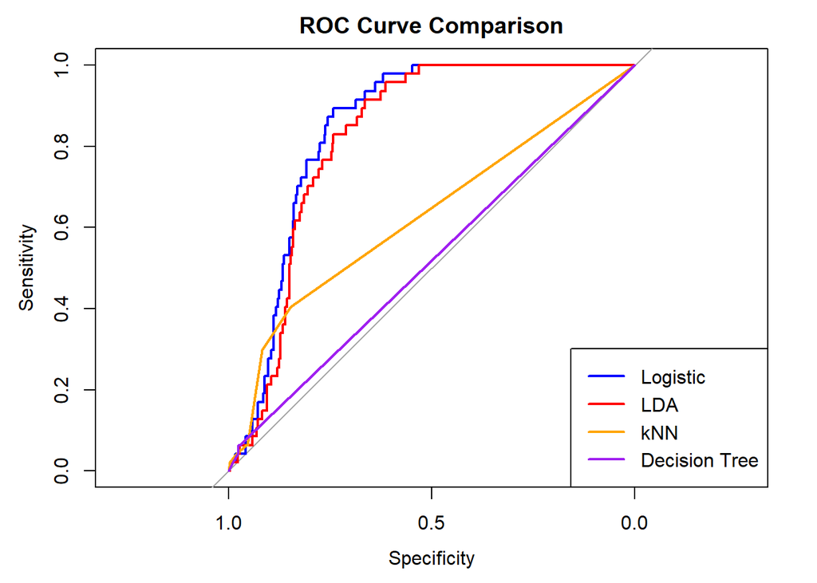

```r
plot(
  log_auc,
  col = "blue",
  lwd = 2,
  main = "ROC Curve Comparison"
)

plot(
  lda_auc,
  col = "red",
  add = TRUE,
  lwd = 2
)

if(exists("qda_auc")){

plot(
  qda_auc,
  col = "darkgreen",
  add = TRUE,
  lwd = 2
)

}

plot(
  knn_auc,
  col = "orange",
  add = TRUE,
  lwd = 2
)

plot(
  tree_auc,
  col = "purple",
  add = TRUE,
  lwd = 2
)

legend_labels <- c(
  "Logistic",
  "LDA",
  "kNN",
  "Decision Tree"
)

legend_colors <- c(
  "blue",
  "red",
  "orange",
  "purple"
)


if(exists("qda_auc")){

  legend_labels <- c(
    legend_labels,
    "QDA"
  )

  legend_colors <- c(
    legend_colors,
    "darkgreen"
  )

}


legend(
  "bottomright",
  legend = legend_labels,
  col = legend_colors,
  lwd = 2
)
```

# Discussion

Across multiple statistical learning approaches, physiological stress can be predicted using engineered heart rate features with varying degrees of accuracy. Linear models provide interpretable estimates of feature effects, while nonlinear approaches such as decision trees and k-nearest neighbors capture more flexible relationships between cardiovascular dynamics and experimental condition.

Comparing multiple algorithms demonstrates that predictive performance depends not only on model complexity but also on the characteristics of the physiological features being analyzed.

# Conclusions

This notebook extended previous analyses by comparing several statistical learning algorithms using a common feature engineering pipeline.

These analyses conclude the statistical modeling pipeline developed throughout this project, demonstrating how classical statistical inference, Bayesian methods, mixed-effects modeling, and modern statistical learning can be integrated to analyze physiological time-series data.

# Hierarchical Bayesian Functional Model

Rather than averaging heart rate within each window, we can model physiological responses while accounting for repeated observations from multiple participants.

This hierarchical framework estimates an overall stress effect while allowing each participant to have an individualized baseline heart rate.

```r
bayes_model <- brm(
  heart_rate ~ stress + (1 | subject),
  data = model_data %>%
    slice_sample(n = 5000),
  family = gaussian(),
  chains = 2,
  iter = 500,
  warmup = 250,
  seed = 123,
  refresh = 100
)
summary(bayes_model)
```

```
##  Family: gaussian
##   Links: mu = identity
## Formula: heart_rate ~ stress + (1 | subject)
##    Data: model_data %>% slice_sample(n = 5000) (Number of observations: 5000)
##   Draws: 2 chains, each with iter = 500; warmup = 250; thin = 1;
##          total post-warmup draws = 500
##
## Multilevel Hyperparameters:
## ~subject (Number of levels: 15)
##               Estimate Est.Error l-95% CI u-95% CI Rhat Bulk_ESS Tail_ESS
## sd(Intercept)     8.53      1.66     6.09    12.73 1.02       73      112
##
## Regression Coefficients:
##              Estimate Est.Error l-95% CI u-95% CI Rhat Bulk_ESS Tail_ESS
## Intercept       75.28      2.08    70.30    79.20 1.04       54       88
## stressStress    10.61      0.57     9.52    11.73 1.01      222      229
##
## Further Distributional Parameters:
##       Estimate Est.Error l-95% CI u-95% CI Rhat Bulk_ESS Tail_ESS
## sigma    13.25      0.13    12.98    13.51 1.01      198      259
##
## Draws were sampled using sampling(NUTS). For each parameter, Bulk_ESS
## and Tail_ESS are effective sample size measures, and Rhat is the potential
## scale reduction factor on split chains (at convergence, Rhat = 1).
```

# Posterior Estimates

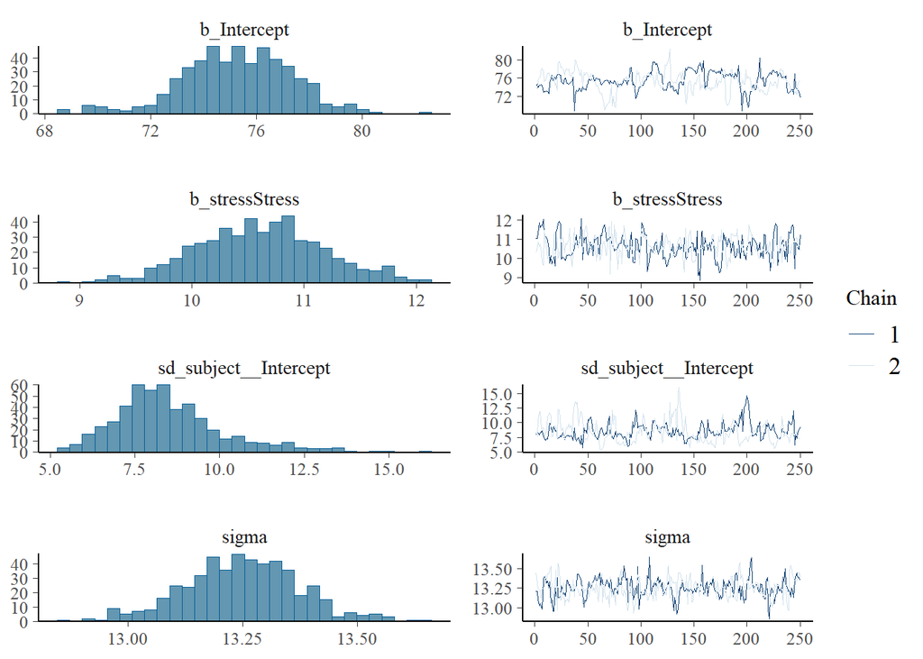

```r
plot(bayes_model)
```

# Posterior Predictive Checks

```r
pp_check(bayes_model)
```

```
## Using 10 posterior draws for ppc type 'dens_overlay' by default.
```

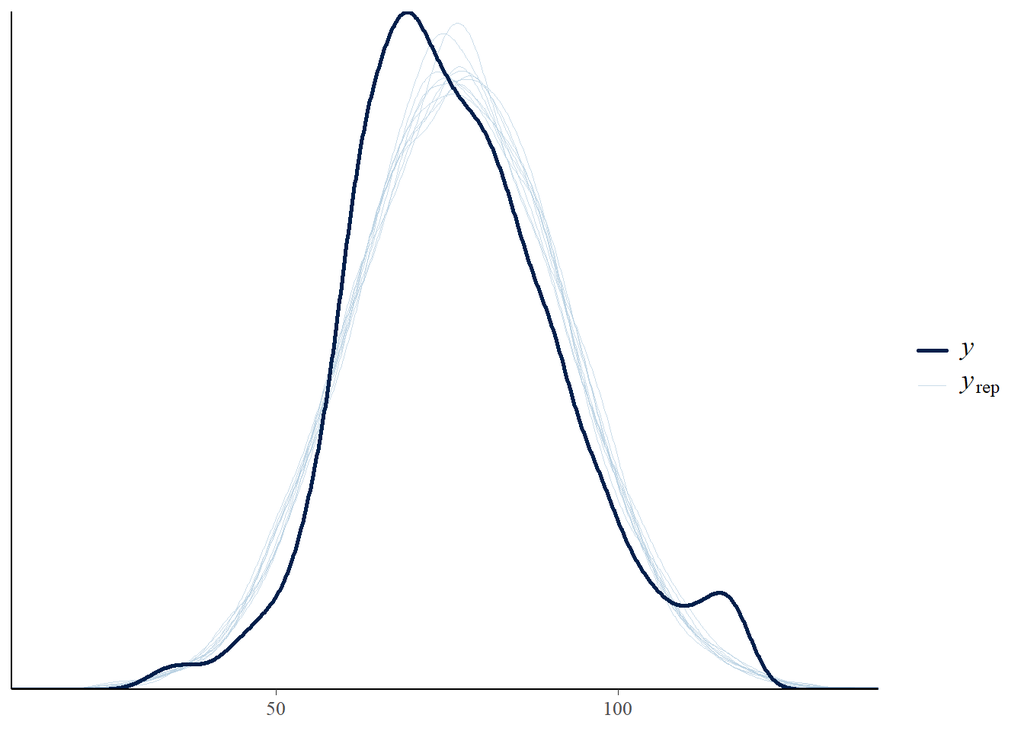

# Estimated Stress Effect

```r
fixef(bayes_model)
```

```
##              Estimate Est.Error      Q2.5    Q97.5
## Intercept    75.28058 2.0783522 70.299354 79.20456
## stressStress 10.61188 0.5653387  9.518015 11.73166
```

# Interpretation

The Bayesian hierarchical model estimates both:

- a population-level stress effect
- subject-specific deviations

This approach naturally accounts for repeated measurements and uncertainty while borrowing information across participants.

Compared with classical mixed-effects models, Bayesian inference provides full posterior distributions rather than single point estimates.

# Discussion

This notebook demonstrates how functional physiological signals can be analyzed using a modern Bayesian framework.

Across this project we have progressed from exploratory visualization to increasingly sophisticated statistical methodology:

- preprocessing raw ECG signals
- estimating heart rate
- computing HRV metrics
- functional data analysis
- statistical inference
- machine learning
- multisubject mixed-effects models
- Bayesian hierarchical modeling

Together these analyses illustrate a complete statistical workflow for physiological signal analysis using reproducible methods.

# Future Directions

Several natural extensions remain.

Future work could include:

- nonlinear Gaussian process models
- Bayesian functional regression
- subject-specific change point detection
- deep learning for physiological time series
- wearable sensor applications
- clinical stress monitoring
- digital biomarkers for neurological and psychiatric disorders

# Conclusions

This project demonstrates an end-to-end reproducible statistical analysis pipeline for physiological signal processing.

Starting from raw ECG recordings in the WESAD dataset, the workflow transformed noisy physiological measurements into interpretable statistical models capable of characterizing stress-related cardiovascular responses.

The analyses incorporated signal processing, feature engineering, exploratory visualization, functional data analysis, generalized linear models, machine learning, mixed-effects modeling, and Bayesian hierarchical inference.

Beyond producing predictive models, the project emphasizes statistical methodology for handling complex biomedical data and illustrates how principled modeling can improve interpretation of physiological responses.

The modular structure of this pipeline provides a foundation for future research integrating additional physiological modalities, personalized modeling strategies, and advanced Bayesian approaches for biomedical signal analysis.